# Exploration of the National Emissions Inventory

Kevin Bitinsky

09/05/2020

## Introduction

The purpose of this project is to explore data within the National Emissions Inventory of the United States Environmental Protection Agency. This is an assignment for the Coursera Johns Hopkins Data Exploratory Data Analysis course.

## Background

Fine particulate matter (PM2.5) is an ambient air pollutant for which there is strong evidence that it is harmful to human health. In the United States, the Environmental Protection Agency (EPA) is tasked with setting national ambient air quality standards for fine PM and for tracking the emissions of this pollutant into the atmosphere. Approximatly every 3 years, the EPA releases its database on emissions of PM2.5. This database is known as the National Emissions Inventory (NEI). You can read more information about the NEI at the EPA National Emissions Inventory web site.

For each year and for each type of PM source, the NEI records how many tons of PM2.5 were emitted from that source over the course of the entire year. The data that you will use for this assignment are for 1999, 2002, 2005, and 2008.

## Data

The data for this assignment are available from the course web site as a single zip file, [Data for Peer Assessment](https://d396qusza40orc.cloudfront.net/exdata%2Fdata%2FNEI_data.zip) The zip file contains two files:

- textsummarySCC_PM25.rds contains a data frame with all of the PM2.5 emissions data for 1999, 2002, 2005, and 2008. For each year, the table contains number of tons of PM2.5 emitted from a specific type of source for the entire year. The columns are as follows:
  - fips: A five-digit number (represented as a string) indicating the U.S. county
  - SCC: The name of the source as indicated by a digit string (see source code classification table)
  - Pollutant: A string indicating the pollutant
  - Emissions: Amount of PM2.5 emitted, in tons
  - type: The type of source (point, non-point, on-road, or non-road)
  - year: The year of emissions recorded
- Source_Classification_Code.rds is a table that provides a mapping from the SCC digit strings in the Emissions table to the actual name of the PM2.5 source. The sources are categorized in a few different ways from more general to more specific and you may choose to explore whatever categories you think are most useful. For example, source “10100101” is known as “Ext Comb /Electric Gen /Anthracite Coal /Pulverized Coal”.

## Analysis

### Data Retrieval

```r
ifelse(!dir.exists(file.path("data")), dir.create(file.path("data")), "Directory already exists")
```

```
## [1] "Directory already exists"
```

```r
url <- "https://d396qusza40orc.cloudfront.net/exdata%2Fdata%2FNEI_data.zip"
destfile <- "./data/Dataset.zip"

if (!file.exists(destfile)) {
  download.file(url ,destfile,method="auto")
  unzip(destfile,exdir="./data")
}

## This first line will likely take a few seconds. Be patient!
NEI <- readRDS("./data/summarySCC_PM25.rds")
SCC <- readRDS("./data/Source_Classification_Code.rds")
```

### Data Examination

```r
str(NEI)
```

```
## 'data.frame':    6497651 obs. of  6 variables:
##  $ fips     : chr  "09001" "09001" "09001" "09001" ...
##  $ SCC      : chr  "10100401" "10100404" "10100501" "10200401" ...
##  $ Pollutant: chr  "PM25-PRI" "PM25-PRI" "PM25-PRI" "PM25-PRI" ...
##  $ Emissions: num  15.714 234.178 0.128 2.036 0.388 ...
##  $ type     : chr  "POINT" "POINT" "POINT" "POINT" ...
##  $ year     : int  1999 1999 1999 1999 1999 1999 1999 1999 1999 1999 ...
```

```r
str(SCC)
```

```
## 'data.frame':    11717 obs. of  15 variables:
##  $ SCC                : Factor w/ 11717 levels "10100101","10100102",..: 1 2 3 4 5 6 7 8 9 10 ...
##  $ Data.Category      : Factor w/ 6 levels "Biogenic","Event",..: 6 6 6 6 6 6 6 6 6 6 ...
##  $ Short.Name         : Factor w/ 11238 levels "","2,4-D Salts and Esters Prod /Process Vents, 2,4-D Recovery: Filtration",..: 3283 3284 3293 3291 3290 3294 3295 3296 3292 3289 ...
##  $ EI.Sector          : Factor w/ 59 levels "Agriculture - Crops & Livestock Dust",..: 18 18 18 18 18 18 18 18 18 18 ...
##  $ Option.Group       : Factor w/ 25 levels "","C/I Kerosene",..: 1 1 1 1 1 1 1 1 1 1 ...
##  $ Option.Set         : Factor w/ 18 levels "","A","B","B1A",..: 1 1 1 1 1 1 1 1 1 1 ...
##  $ SCC.Level.One      : Factor w/ 17 levels "Brick Kilns",..: 3 3 3 3 3 3 3 3 3 3 ...
##  $ SCC.Level.Two      : Factor w/ 146 levels "","Agricultural Chemicals Production",..: 32 32 32 32 32 32 32 32 32 32 ...
##  $ SCC.Level.Three    : Factor w/ 1061 levels "","100% Biosolids (e.g., sewage sludge, manure, mixtures of these matls)",..: 88 88 156 156 156 156 156 156 156 156 ...
##  $ SCC.Level.Four     : Factor w/ 6084 levels "","(NH4)2 SO4 Acid Bath System and Evaporator",..: 4455 5583 4466 4458 1341 5246 5584 5983 4461 776 ...
##  $ Map.To             : num  NA NA NA NA NA NA NA NA NA NA ...
##  $ Last.Inventory.Year: int  NA NA NA NA NA NA NA NA NA NA ...
##  $ Created_Date       : Factor w/ 57 levels "","1/27/2000 0:00:00",..: 1 1 1 1 1 1 1 1 1 1 ...
##  $ Revised_Date       : Factor w/ 44 levels "","1/27/2000 0:00:00",..: 1 1 1 1 1 1 1 1 1 1 ...
##  $ Usage.Notes        : Factor w/ 21 levels ""," ","includes bleaching towers, washer hoods, filtrate tanks, vacuum pump exhausts",..: 1 1 1 1 1 1 1 1 1 1 ...
```

It can be confirmed that NEI contains the emissions data, while SCC provides detailed information on for each classification. So SCC may be used as a primary key to merge the two tables, if required.

### Questions:

#### Q1: Have total emissions from PM2.5 decreased in the United States from 1999 to 2008? Using the base plotting system, make a plot showing the total PM2.5 emission from all sources for each of the years 1999, 2002, 2005, and 2008?

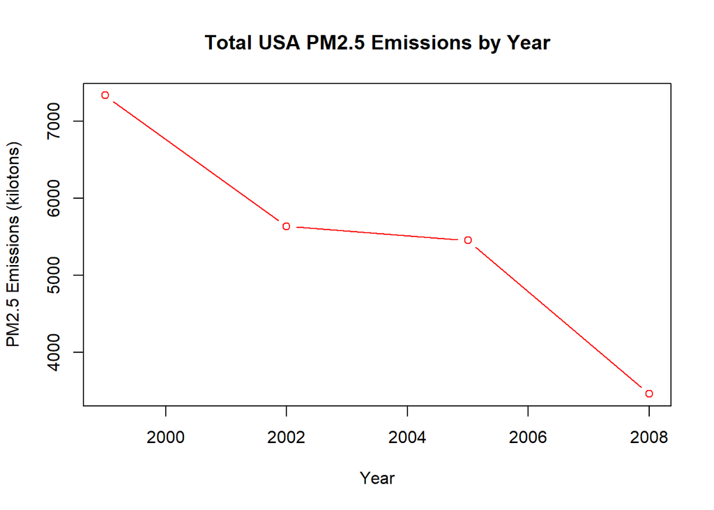

```r
plot(NEI %>% group_by(year) %>% summarize(sum(Emissions)/1000),
          type = "b",
          col = "red",
          main = ("Total USA PM2.5 Emissions by Year"),
          ylab = ("PM2.5 Emissions (kilotons)"),
          xlab = "Year")
```

You can see that the total PM2.5 American emissions have decreased from 1999 to 2008.

#### Q2: Have total emissions from PM2.5 decreased in the Baltimore City, Maryland (fips == “24510”) from 1999 to 2008? Use the base plotting system to make a plot answering this question.

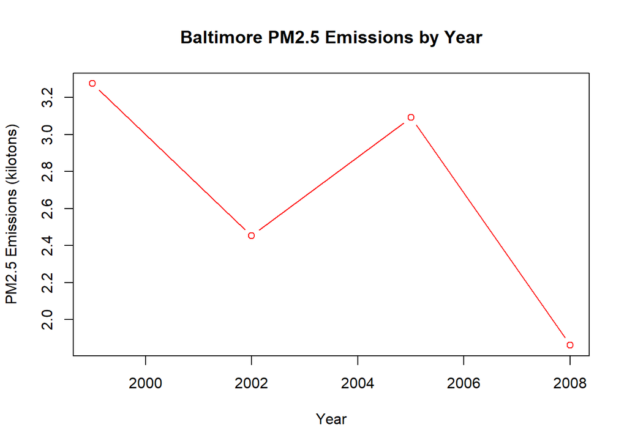

```r
plot(NEI %>%
       filter(fips == 24510) %>%
       group_by(year) %>%
       summarize(sum(Emissions)/1000),
     type = "b",
     col = "red",
     main = ("Baltimore PM2.5 Emissions by Year"),
     ylab = ("PM2.5 Emissions (kilotons)"),
     xlab = "Year")
```

You can see that the PM2.5 emissions from Baltimore Maryland have decreased when comparing 1999 to 2008, although it may be noted that they did go up at some point during that time.

#### Q3: Of the four types of sources indicated by the type (point, nonpoint, onroad, nonroad) variable, which of these four sources have seen decreases in emissions from 1999–2008 for Baltimore City? Which have seen increases in emissions from 1999–2008? Use the ggplot2 plotting system to make a plot answer this question.

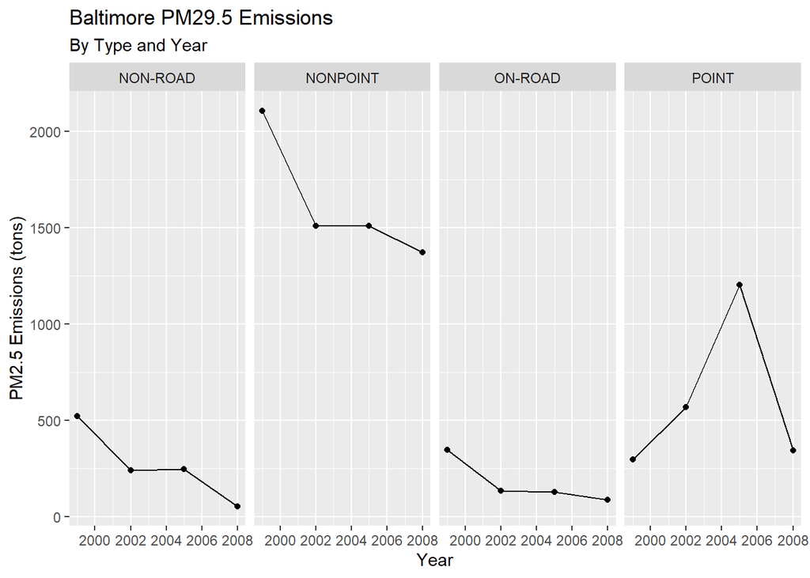

```r
NEI %>%
  filter(fips == 24510) %>%
  group_by(year, type) %>%
  summarize(Emissions = sum(Emissions)) %>%
  ggplot(aes(year, Emissions)) +
         geom_point() +
         geom_line() +
         facet_grid(. ~ type) +
         ggtitle("Baltimore PM29.5 Emissions", subtitle = "By Type and Year") +
         ylab("PM2.5 Emissions (tons)") +
         xlab("Year")
```

All type of emissions except for point-type in Baltimore decreased from 1999 to 2008.

#### Q4: Across the United States, how have emissions from coal combustion-related sources changed from 1999–2008?

Examine the factor variables in SCC for coal-combustion, also explore the free text fields for clues as to what might be relevant. Note that I’m only displaying the top ten results for each exploration, to provide context.

```r
head(unique(SCC$Data.Category), n=10)
```

```
## [1] Point    Nonpoint Onroad   Nonroad  Biogenic Event
## Levels: Biogenic Event Nonpoint Nonroad Onroad Point
```

```r
head(unique(SCC$EI.Sector), n=10)
```

```
##  [1] Fuel Comb - Electric Generation - Coal
##  [2] Fuel Comb - Electric Generation - Oil
##  [3] Fuel Comb - Electric Generation - Natural Gas
##  [4] Fuel Comb - Electric Generation - Other
##  [5] Fuel Comb - Electric Generation - Biomass
##  [6] Fuel Comb - Industrial Boilers, ICEs - Coal
##  [7] Fuel Comb - Industrial Boilers, ICEs - Oil
##  [8] Fuel Comb - Industrial Boilers, ICEs - Natural Gas
##  [9] Fuel Comb - Industrial Boilers, ICEs - Other
## [10] Fuel Comb - Industrial Boilers, ICEs - Biomass
## 59 Levels: Agriculture - Crops & Livestock Dust ...
```

```r
head(unique(SCC$Option.Group), n=10)
```

```
##  [1]                      C/I Kerosene         RWC_Fireplace
##  [4] RWC_StoveInserts     RWC_StoveFreeStand   RWC_StovePellet
##  [7] RWC_Furnace_cordwood RWC_Furnace_pellet   RWC_Hydronic
## [10] Paved Roads
## 25 Levels:  C/I Kerosene Cattle Commercial Construction ... WW Treatment
```

```r
head(SCC %>% filter(grepl("coal",Short.Name, ignore.case = TRUE)) %>% select(Short.Name), n=10)
```

```
##                                                                           Short.Name
## 1                           Ext Comb /Electric Gen /Anthracite Coal /Pulverized Coal
## 2         Ext Comb /Electric Gen /Anthracite Coal /Traveling Grate (Overfeed) Stoker
## 3               Ext Comb /Electric Gen /Bituminous Coal /Pulverized Coal: Wet Bottom
## 4               Ext Comb /Electric Gen /Bituminous Coal /Pulverized Coal: Dry Bottom
## 5                           Ext Comb /Electric Gen /Bituminous Coal /Cyclone Furnace
## 6                           Ext Comb /Electric Gen /Bituminous Coal /Spreader Stoker
## 7         Ext Comb /Electric Gen /Bituminous Coal /Traveling Grate (Overfeed) Stoker
## 8                   Ext Comb /Electric Gen /Bituminous Coal /Wet Bottom (Tangential)
## 9  Ext Comb /Electric Gen /Bituminous Coal /Pulverized Coal: Dry Bottom (Tangential)
## 10                              Ext Comb /Electric Gen /Bituminous Coal /Cell Burner
```

Assume that the *EI.Sector* provides the closest match to what we’re looking for. Select all SCC where there is fuel combustion from coal.

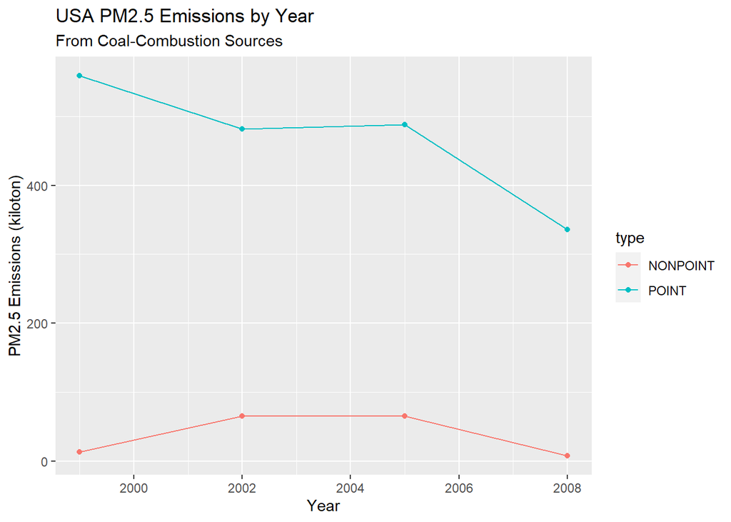

```r
sources <- SCC %>%
  filter(grepl("coal", EI.Sector, ignore.case = TRUE)) %>%
  select(SCC, EI.Sector)

NEI %>%
  filter(SCC %in% sources$SCC) %>%
  group_by(year, type) %>%
  summarize(Emissions = sum(Emissions)/1000) %>%
  ggplot(aes(year, Emissions, col = type)) +
  geom_point() +
  geom_line() +
  ggtitle("USA PM2.5 Emissions by Year", subtitle = "From Coal-Combustion Sources") +
  ylab("PM2.5 Emissions (kiloton)") +
  xlab("Year")
```

For coal-combustion emissions the point-type have dropped from 1999 to 2008. Nonpoint-type emissions have remained overall flat across that same timeframe, however, they have been almost zero.

#### Q5: How have emissions from motor vehicle sources changed from 1999–2008 in Baltimore City?

```r
sources <- SCC %>%
  filter(grepl("vehicle", EI.Sector, ignore.case = TRUE)) %>%
  select(SCC, EI.Sector)

head(sources, n = 10)
```

```
##           SCC                                     EI.Sector
## 1  2201001000 Mobile - On-Road Gasoline Light Duty Vehicles
## 2  2201001110 Mobile - On-Road Gasoline Light Duty Vehicles
## 3  2201001111 Mobile - On-Road Gasoline Light Duty Vehicles
## 4  2201001112 Mobile - On-Road Gasoline Light Duty Vehicles
## 5  2201001113 Mobile - On-Road Gasoline Light Duty Vehicles
## 6  2201001114 Mobile - On-Road Gasoline Light Duty Vehicles
## 7  220100111B Mobile - On-Road Gasoline Light Duty Vehicles
## 8  220100111T Mobile - On-Road Gasoline Light Duty Vehicles
## 9  220100111V Mobile - On-Road Gasoline Light Duty Vehicles
## 10 220100111X Mobile - On-Road Gasoline Light Duty Vehicles
```

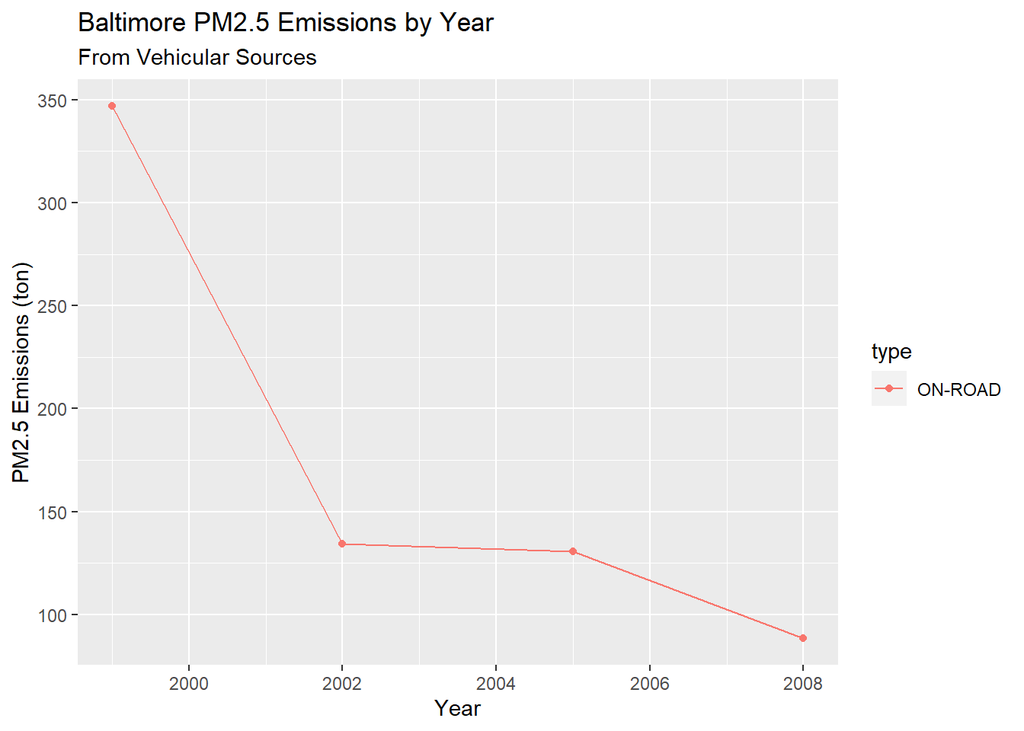

```r
NEI %>%
  filter(SCC %in% sources$SCC, fips == 24510) %>%
  group_by(year, type) %>%
  summarize(Emissions = sum(Emissions)) %>%
  ggplot(aes(year, Emissions, col = type)) +
  geom_point() +
  geom_line() +
  ggtitle("Baltimore PM2.5 Emissions by Year", subtitle = "From Vehicular Sources") +
  ylab("PM2.5 Emissions (ton)") +
  xlab("Year")
```

Emissions from motor vehicle sources have dropped from 1999 to 2008. It also appears that “on-road” is the only type that matters for this source.

#### Q6: Compare emissions from motor vehicle sources in Baltimore City with emissions from motor vehicle sources in Los Angeles County, California (fips == “06037”). Which city has seen greater changes over time in motor vehicle emissions?

What we learned in the previous question is that the on-road type is the factor that we could look at for vehicular sources.

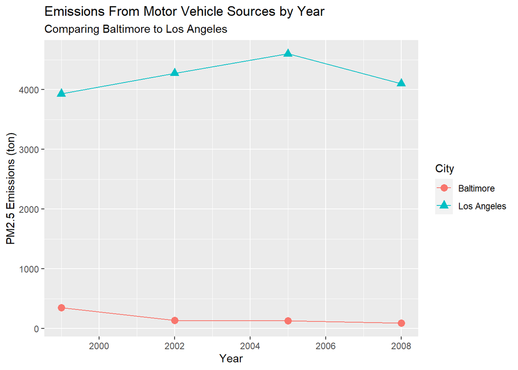

```r
NEI %>%
  filter(fips %in% c("24510","06037"), type == "ON-ROAD") %>%
  group_by(year, fips) %>%
  summarize(Emissions = sum(Emissions)) %>%
  mutate(City = ifelse(fips == "06037","Los Angeles",
                       ifelse(fips == "24510", "Baltimore", "error"))) %>%
  ggplot(aes(year, Emissions, col = City)) +
  geom_point(aes(shape = City), size = 3) +
  geom_line() +
  ggtitle("Emissions From Motor Vehicle Sources by Year",
          subtitle = "Comparing Baltimore to Los Angeles") +
  ylab("PM2.5 Emissions (ton)") +
  xlab("Year")
```

It can be seen that Los Angeles has much higher emissions from vehicles and has seen greater changes over time.